# Lab 4

### Keira Hansen and Alex Foster

## Problem 1

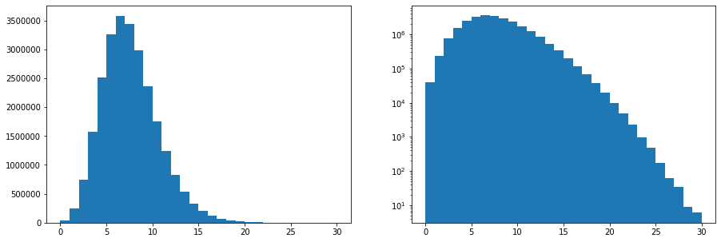

```python
%matplotlib inline
import numpy as np
import matplotlib
import matplotlib.pyplot as plt
import scipy
from scipy import stats
from scipy.optimize import curve_fit
import h5py

hf = h5py.File('gammaray_lab4.h5', 'r')
data = np.array(hf.get('data'))
hf.close()

time = data[0,:]
phase = data[1,:]
longitude = data[2,:]
counts = data[3,:]

fig, ax = plt.subplots(1, 2, figsize=(15, 5))

ax[0].hist(counts, 30)

ax[1].hist(counts, 30)
ax[1].set_yscale('log')

plt.show()
```

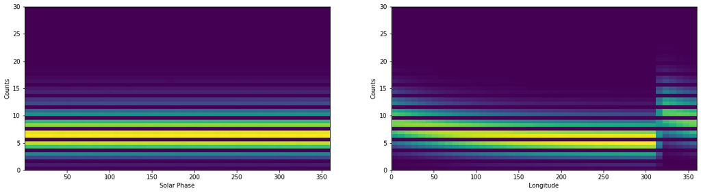

```python
fig, ax = plt.subplots(1, 2, figsize=(20, 5))

ax[0].hist2d(phase, counts, 45)
ax[0].set_xlabel('Solar Phase')
ax[0].set_ylabel('Counts')

ax[1].hist2d(longitude, counts, 45)
ax[1].set_xlabel('Longitude')
ax[1].set_ylabel('Counts')
plt.show()
```

> I then thought it would be interesting to see a histogram for counts versus the other meta data we were given. The plot on the left is a 2D histogram of counts versus solar phase. My interpretation of this plot is that the counts do not depend of solar phase since the distribution remains constant for all degrees.

> The plot on the right is a 2D histogram of counts versus longitude. On the right plot there is a feature of the data where it appears the counts do not have a constant distribution vs longitude and there is a discontinuity at 310 degrees. My best interpretation of this plot is that the counts do have a dependence on the longitude it is at relative to the earth, with a phase shift of +310 degrees (or -50 degrees).

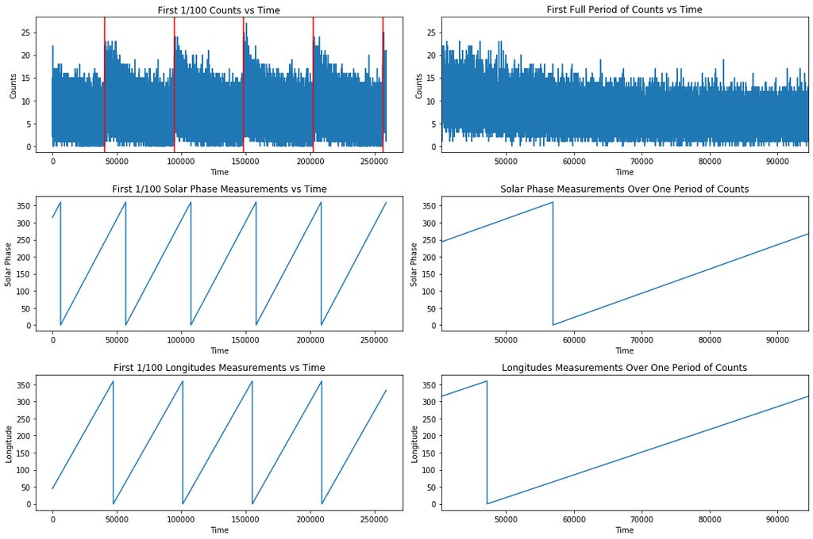

```python
first_stop = int(len(time) / 100)

first_counts_part = counts[:first_stop]
first_phase_part = phase[:first_stop]
first_longitude_part = longitude[:first_stop]

fig, ax = plt.subplots(3, 2, figsize=(15, 10))
ax[0, 0].plot(first_time_part, first_counts_part)
ax[0, 0].set_title('First 1/100 Counts vs Time')
ax[0, 0].set_xlabel('Time')
ax[0, 0].set_ylabel('Counts')
ax[0, 0].axvline(x=40500, color='r', label='x = 40500')
ax[0, 0].axvline(x=94500, color='r', label='x = 94500')
ax[0, 0].axvline(x=148500, color='r', label='x = 148500')
ax[0, 0].axvline(x=202500, color='r', label='x = 193500')
ax[0, 0].axvline(x=256500, color='r', label='x = 238500')

ax[0, 1].plot(first_time_part, first_counts_part)
ax[0, 1].set_title('First Full Period of Counts vs Time')
ax[0, 1].set_xlabel('Time')
ax[0, 1].set_ylabel('Counts')
ax[0, 1].set_xlim(40500, 94500)

ax[1, 0].plot(first_time_part, first_phase_part)
ax[1, 0].set_title('First 1/100 Solar Phase Measurements vs Time')
ax[1, 0].set_xlabel('Time')
ax[1, 0].set_ylabel('Solar Phase')

ax[1, 1].plot(first_time_part, first_phase_part)
ax[1, 1].set_title('Solar Phase Measurements Over One Period of Counts')
ax[1, 1].set_xlabel('Time')
ax[1, 1].set_ylabel('Solar Phase')
ax[1, 1].set_xlim(40500, 94500)

ax[2, 0].plot(first_time_part, first_longitude_part)
ax[2, 0].set_title('First 1/100 Longitudes Measurements vs Time')
ax[2, 0].set_xlabel('Time')
ax[2, 0].set_ylabel('Longitude')

ax[2, 1].plot(first_time_part, first_longitude_part)
ax[2, 1].set_title('Longitudes Measurements Over One Period of Counts')
ax[2, 1].set_xlabel('Time')
ax[2, 1].set_ylabel('Longitude')
ax[2, 1].set_xlim(40500, 94500)

plt.tight_layout()
plt.show()
```

> I then ploted the first 1/100 solar phase and longitude measurements vs time. The plots next to them show the trends in the solar phase and longitude over the interval I have selected to represent the trend during one period of the counts. From the plots above we have determined that the phase of the sun doesn't affect the counts, so even though the solar phase does depend in time it's fluxuation doesn't correspond to the fluxuation in the counts. The longitude versus time however does, also determined above in the 2D histogram, and here we can see that the phase of the longitude has been shifted due to the time period I have chosen.

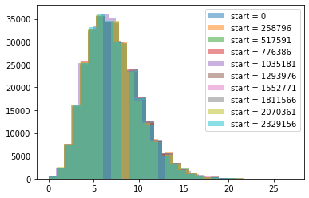

```python
counts_length = len(counts)
stops = []
for i in range(10):
    stops.append(int((i + 1) * (counts_length / 100)))

for i in range(len(stops)):
    if i == 0:
        start = 0
    else:
        start = stops[i - 1] + 1

    stop = stops[i]
    plt.hist(counts[start:stop], 30, alpha=0.5, label='start = ' + str(start))

plt.legend(loc='best')
plt.show()
```

> We can average the all the full periods from the entire data set to get an average period which can we can then fit a function to and find a good approximation of the background over one period of counts. By averaging, if a signal is produced only in a small handfull of periods it's contribution will be scaled to however many periods it appeared in over all the periods which for a large number of periods will almost be zero. Whereas if a signal comes through for every period it is most likely caused by the background and it's contribution will be scaled to about it's original value. This leaves us with an approximation of the background signal.

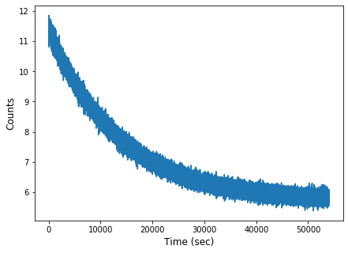

```python
counts = counts[40500:]

period = 54000
counts_parts = []
average_counts = []
for i in range(400):
    start = i * period
    stop = (i + 1) * period
    counts_parts.append(np.array(counts[start:stop]))
    average_counts.append(np.true_divide(np.sum(counts[start:stop]), len(counts[start:stop])))

averaged_data = np.zeros(54000)
total_parts = len(counts_parts)
for part in counts_parts:
    averaged_data = np.add(averaged_data, part)

averaged_data = np.true_divide(averaged_data, total_parts)

time_for_average = np.arange(0, period)

fig, ax = plt.subplots(1, 1, figsize=(7, 5))
ax.plot(time_for_average, averaged_data)
ax.set_xlabel('Time (sec)', fontsize='large')
ax.set_ylabel('Counts', fontsize='large')
plt.show()
```

> The plot above shows the averaged period which I am going to fit a function to that I will use as my background. By averaging all the periods together the overall noise has been greatly reduced. The overall trend of the curve appears to be a decaying exponential $N(t)=a\,e^{-b t}+c$. The only problem is that the time scale is so large that computers can't handle that many figures.

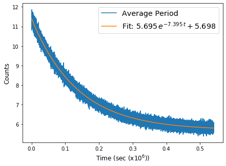

```python
def func(x, a, b, c):
    return a * np.exp(-b * x) + c

reduced_time = np.linspace(0, period / 100000, period)

popt, pcov = curve_fit(func, reduced_time, averaged_data)

fig, ax = plt.subplots(1, 1, figsize=(7, 5))

ax.plot(reduced_time, averaged_data, label='Average Period')
ax.plot(reduced_time, func(reduced_time, *popt), label='Fit: $%5.3f\,e^{-%5.3f\,t} + %5.3f$' % tuple(popt))
ax.set_xlabel('Time (sec (x$10^{6}$))', fontsize='large')
ax.set_ylabel('Counts', fontsize='large')
ax.legend(loc='best', fontsize='x-large')

plt.show()
```

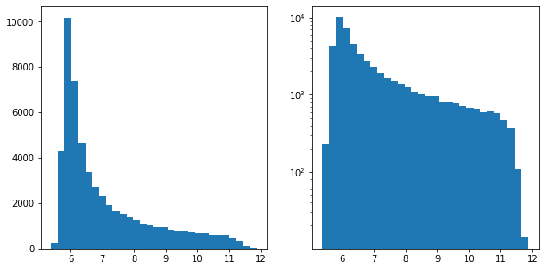

```python
fig, ax = plt.subplots(1, 2, figsize=(10, 5))

ax[0].hist(averaged_data, 30)
ax[1].hist(averaged_data, 30)
ax[1].set_yscale('log')

plt.show()
```

> I thought it would be a good idea to plot the distibution of counts over the average period that represented the background I determined above. I have to be honest I don't really understand why it no longer looks like a Poisson distribution like that in the very first plot. I thought I would keep it in my report since it surely means something but I would have to spend a lot more time working on it.

```python
prob = stats.norm.cdf(5)
signal1 = stats.poisson.ppf(prob, average_counts[1])
signal2 = stats.poisson.ppf(prob, average_counts[27])
signal3 = stats.poisson.ppf(prob, average_counts[299])

print('Average number of counts for 2nd period =', average_counts[1])
print('Average number of counts for 28th period =', average_counts[27])
print('Average number of counts for 300th period =', average_counts[299])
print()
print('5\u03C3 for 2nd Period = %5.2f gamma rays' % signal1)
print('5\u03C3 for 28th Period = %5.2f gamma rays' % signal2)
print('5\u03C3 for 300th Period = %5.2f gamma rays' % signal3)
```

```
Average number of counts for 2nd period = 7.124314814814815
Average number of counts for 28th period = 7.087018518518518
Average number of counts for 300th period = 7.0979074074074076

5σ for 2nd Period = 24.00 gamma rays
5σ for 28th Period = 24.00 gamma rays
5σ for 300th Period = 24.00 gamma rays
```

> For the 2nd period of counts the number of gamma rays needed to have a measurement of 5$\sigma$ significance is 24. This is the same for the 28th period of counts and the 300th period of counts. I thought this was suspisious so I printed out the average number of counts per period, which corresponds to the shape factor in Poisson pmf, and they were not all the same so I believe that the number of decimals the number of rays goes out to must be very insignificant.

## Problem 2

```python
%matplotlib inline
import numpy as np
import matplotlib
import matplotlib.pyplot as plt
import scipy
from scipy import stats
from scipy.optimize import curve_fit
import h5py

hf = h5py.File('images.h5', 'r')
imagestack = np.array(hf.get('imagestack'))
hf.close()
```

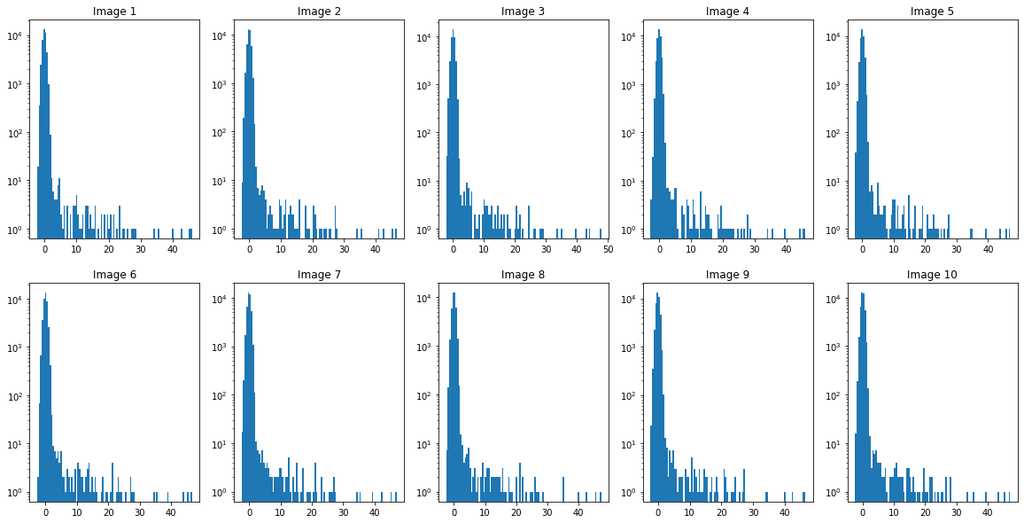

```python
fig, ax = plt.subplots(2, 5, figsize=(20, 10))
plots = []
for i in range(10):
    pixel_values = []
    for j in range(200):
        pixel_values.extend(imagestack[j,:,i])
    plots.append(pixel_values)

    if i < 5:
        row_index = 0
        col_index = i
    else:
        row_index = 1
        col_index = i - 5
    ax[row_index, col_index].hist(pixel_values, 100)
    ax[row_index, col_index].set_title('Image %d' % (i + 1))
    ax[row_index, col_index].set_yscale('log')
plt.show()
```

> The plots above show the distribution of pixel intensities for each image.

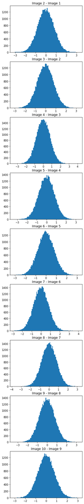

```python
fig, ax = plt.subplots(9, 1, figsize=(5, 35))

all_differences = []

for i in range(9):
    differences = []
    background_pixels = []
    for j in range(200):
        sub = np.subtract(imagestack[j, :, i], imagestack[j, :, i + 1])
        differences.extend(sub)
        background_pixels.append(sub)

    all_differences.append(background_pixels)
    ax[i].hist(differences, 100)
    ax[i].set_title('Image ' + str(i + 2) + ' - Image ' + str(i + 1))
plt.show()
```

> Since I am looking for transients, things that only show up in one image. I want to model the background signal that changes between images so I can find the required difference in pixel intensity of a 5$\sigma$ detection of a transient. The plots above are the distributions of the change in pixel intensity between each image. An average of these plots will give us a good background approximation that we can use to calculate what changes in pixel intensity from image to image is a justified transient signal and not the normal background noise.

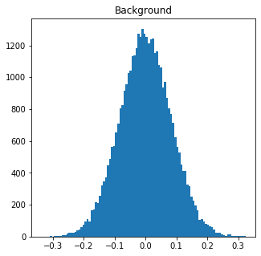

```python
background = np.zeros((200, 200))
all_differences = np.array(all_differences)

for i in range(9):
    for j in range(200):
        val = np.add(background[j, :], all_differences[i, j, :])
        avg = np.true_divide(val, 9)
        background[j] = avg

background_pixels = []
for i in range(200):
    background_pixels.extend(background[:, i])


fig, ax = plt.subplots(1, 1, figsize=(5, 5))
ax.hist(background_pixels, 100)
ax.set_title('Background')
plt.show()
```

```python
low_bound = 1 - stats.norm.cdf(5)

sum = 0
for i in range(len(background_pixels)):
    if (sum != low_bound):
        sum = sum + background_pixels[i]
print(np.abs(sum) / 4)
```

```
3.0475030107852925
```

> For our measurement to be significant we need a threshhold of 5$\sigma$ on either side of the background distribution. We will then integrate our background from zero out to some unknown value till be reach a probability that is associated with 5$\sigma$. Since our background is a gaussian centered at zero the other bound for 5$\sigma$ will just be reflected onto the negative x-axis. We can therefore conclude that events that are outside of these bounds are signals from transients and not from the background.

> For a transient to have a signal of at least 5$\sigma$ significance the pixel must change by at least $\pm$ 3.0475030107852925 in the plots of the difference between each successive image.

> Since my partner and I are looking for different things the type of distribution we need to describe our data will be different. I am looking for transients, things that only appear in one image, so I am interested in a distribution that represents the total change in pixel intensity. If my partner used my pdf then he would eliminate a lot of the points of interest since faint stars won't not change much between images.